# Risk Factor Analysis

## Outcome Variable

**Outcome Variable:** wasted

## Predictor Variables

**Intervention Variable:** mwtkg

**Adjustment Set:**

unadjusted

## Stratifying Variables

The analysis was stratified on these variable(s):

- agecat
- studyid
- country

## Data Summary

| agecat | studyid | country | mwtkg | wasted | n_cell | n |
| --- | --- | --- | --- | --- | --- | --- |
| Birth | ki0047075b-MAL-ED | BANGLADESH | >=58 kg | 0 | 34 | 209 |
| Birth | ki0047075b-MAL-ED | BANGLADESH | >=58 kg | 1 | 3 | 209 |
| Birth | ki0047075b-MAL-ED | BANGLADESH | <52 kg | 0 | 107 | 209 |
| Birth | ki0047075b-MAL-ED | BANGLADESH | <52 kg | 1 | 24 | 209 |
| Birth | ki0047075b-MAL-ED | BANGLADESH | [52-58) kg | 0 | 33 | 209 |
| Birth | ki0047075b-MAL-ED | BANGLADESH | [52-58) kg | 1 | 8 | 209 |
| Birth | ki0047075b-MAL-ED | BRAZIL | >=58 kg | 0 | 33 | 61 |
| Birth | ki0047075b-MAL-ED | BRAZIL | >=58 kg | 1 | 0 | 61 |
| Birth | ki0047075b-MAL-ED | BRAZIL | <52 kg | 0 | 13 | 61 |
| Birth | ki0047075b-MAL-ED | BRAZIL | <52 kg | 1 | 1 | 61 |
| Birth | ki0047075b-MAL-ED | BRAZIL | [52-58) kg | 0 | 13 | 61 |
| Birth | ki0047075b-MAL-ED | BRAZIL | [52-58) kg | 1 | 1 | 61 |
| Birth | ki0047075b-MAL-ED | INDIA | >=58 kg | 0 | 6 | 41 |
| Birth | ki0047075b-MAL-ED | INDIA | >=58 kg | 1 | 0 | 41 |
| Birth | ki0047075b-MAL-ED | INDIA | <52 kg | 0 | 23 | 41 |
| Birth | ki0047075b-MAL-ED | INDIA | <52 kg | 1 | 5 | 41 |
| Birth | ki0047075b-MAL-ED | INDIA | [52-58) kg | 0 | 7 | 41 |
| Birth | ki0047075b-MAL-ED | INDIA | [52-58) kg | 1 | 0 | 41 |
| Birth | ki0047075b-MAL-ED | NEPAL | >=58 kg | 0 | 9 | 26 |
| Birth | ki0047075b-MAL-ED | NEPAL | >=58 kg | 1 | 0 | 26 |
| Birth | ki0047075b-MAL-ED | NEPAL | <52 kg | 0 | 6 | 26 |
| Birth | ki0047075b-MAL-ED | NEPAL | <52 kg | 1 | 1 | 26 |
| Birth | ki0047075b-MAL-ED | NEPAL | [52-58) kg | 0 | 9 | 26 |
| Birth | ki0047075b-MAL-ED | NEPAL | [52-58) kg | 1 | 1 | 26 |
| Birth | ki0047075b-MAL-ED | PERU | >=58 kg | 0 | 80 | 221 |
| Birth | ki0047075b-MAL-ED | PERU | >=58 kg | 1 | 2 | 221 |
| Birth | ki0047075b-MAL-ED | PERU | <52 kg | 0 | 78 | 221 |
| Birth | ki0047075b-MAL-ED | PERU | <52 kg | 1 | 3 | 221 |
| Birth | ki0047075b-MAL-ED | PERU | [52-58) kg | 0 | 58 | 221 |
| Birth | ki0047075b-MAL-ED | PERU | [52-58) kg | 1 | 0 | 221 |

[output cut: 240 more lines]

The following strata were considered:

- agecat: 24 months, studyid: ki0047075b-MAL-ED, country: BANGLADESH
- agecat: 24 months, studyid: ki0047075b-MAL-ED, country: BRAZIL
- agecat: 24 months, studyid: ki0047075b-MAL-ED, country: INDIA
- agecat: 24 months, studyid: ki0047075b-MAL-ED, country: NEPAL
- agecat: 24 months, studyid: ki0047075b-MAL-ED, country: PERU
- agecat: 24 months, studyid: ki0047075b-MAL-ED, country: SOUTH AFRICA
- agecat: 24 months, studyid: ki0047075b-MAL-ED, country: TANZANIA, UNITED REPUBLIC OF
- agecat: 24 months, studyid: ki1017093-NIH-Birth, country: BANGLADESH
- agecat: 24 months, studyid: ki1017093b-PROVIDE, country: BANGLADESH
- agecat: 24 months, studyid: ki1017093c-NIH-Crypto, country: BANGLADESH
- agecat: 24 months, studyid: ki1066203-TanzaniaChild2, country: TANZANIA, UNITED REPUBLIC OF
- agecat: 24 months, studyid: ki1119695-PROBIT, country: BELARUS
- agecat: 24 months, studyid: ki1126311-ZVITAMBO, country: ZIMBABWE
- agecat: 24 months, studyid: ki1148112-LCNI-5, country: MALAWI
- agecat: 24 months, studyid: kiGH5241-JiVitA-3, country: BANGLADESH
- agecat: 6 months, studyid: ki0047075b-MAL-ED, country: BANGLADESH
- agecat: 6 months, studyid: ki0047075b-MAL-ED, country: BRAZIL
- agecat: 6 months, studyid: ki0047075b-MAL-ED, country: INDIA
- agecat: 6 months, studyid: ki0047075b-MAL-ED, country: NEPAL
- agecat: 6 months, studyid: ki0047075b-MAL-ED, country: PERU
- agecat: 6 months, studyid: ki0047075b-MAL-ED, country: SOUTH AFRICA
- agecat: 6 months, studyid: ki0047075b-MAL-ED, country: TANZANIA, UNITED REPUBLIC OF
- agecat: 6 months, studyid: ki1000304b-SAS-CompFeed, country: INDIA
- agecat: 6 months, studyid: ki1017093-NIH-Birth, country: BANGLADESH
- agecat: 6 months, studyid: ki1017093b-PROVIDE, country: BANGLADESH
- agecat: 6 months, studyid: ki1017093c-NIH-Crypto, country: BANGLADESH
- agecat: 6 months, studyid: ki1066203-TanzaniaChild2, country: TANZANIA, UNITED REPUBLIC OF
- agecat: 6 months, studyid: ki1119695-PROBIT, country: BELARUS
- agecat: 6 months, studyid: ki1126311-ZVITAMBO, country: ZIMBABWE
- agecat: 6 months, studyid: ki1148112-LCNI-5, country: MALAWI
- agecat: 6 months, studyid: kiGH5241-JiVitA-3, country: BANGLADESH
- agecat: Birth, studyid: ki0047075b-MAL-ED, country: BANGLADESH
- agecat: Birth, studyid: ki0047075b-MAL-ED, country: BRAZIL
- agecat: Birth, studyid: ki0047075b-MAL-ED, country: INDIA
- agecat: Birth, studyid: ki0047075b-MAL-ED, country: NEPAL
- agecat: Birth, studyid: ki0047075b-MAL-ED, country: PERU
- agecat: Birth, studyid: ki0047075b-MAL-ED, country: SOUTH AFRICA
- agecat: Birth, studyid: ki0047075b-MAL-ED, country: TANZANIA, UNITED REPUBLIC OF
- agecat: Birth, studyid: ki1000304b-SAS-CompFeed, country: INDIA
- agecat: Birth, studyid: ki1017093-NIH-Birth, country: BANGLADESH
- agecat: Birth, studyid: ki1017093b-PROVIDE, country: BANGLADESH
- agecat: Birth, studyid: ki1017093c-NIH-Crypto, country: BANGLADESH
- agecat: Birth, studyid: ki1119695-PROBIT, country: BELARUS
- agecat: Birth, studyid: ki1126311-ZVITAMBO, country: ZIMBABWE
- agecat: Birth, studyid: kiGH5241-JiVitA-3, country: BANGLADESH

### Dropped Strata

Some strata were dropped due to rare outcomes:

- agecat: Birth, studyid: ki0047075b-MAL-ED, country: BANGLADESH
- agecat: Birth, studyid: ki0047075b-MAL-ED, country: BRAZIL
- agecat: Birth, studyid: ki0047075b-MAL-ED, country: INDIA
- agecat: Birth, studyid: ki0047075b-MAL-ED, country: NEPAL
- agecat: Birth, studyid: ki0047075b-MAL-ED, country: PERU
- agecat: Birth, studyid: ki0047075b-MAL-ED, country: SOUTH AFRICA
- agecat: Birth, studyid: ki0047075b-MAL-ED, country: TANZANIA, UNITED REPUBLIC OF
- agecat: 6 months, studyid: ki0047075b-MAL-ED, country: BANGLADESH
- agecat: 6 months, studyid: ki0047075b-MAL-ED, country: BRAZIL
- agecat: 6 months, studyid: ki0047075b-MAL-ED, country: INDIA
- agecat: 6 months, studyid: ki0047075b-MAL-ED, country: NEPAL
- agecat: 6 months, studyid: ki0047075b-MAL-ED, country: PERU
- agecat: 6 months, studyid: ki0047075b-MAL-ED, country: SOUTH AFRICA
- agecat: 6 months, studyid: ki0047075b-MAL-ED, country: TANZANIA, UNITED REPUBLIC OF
- agecat: 6 months, studyid: ki1017093-NIH-Birth, country: BANGLADESH
- agecat: 6 months, studyid: ki1017093b-PROVIDE, country: BANGLADESH
- agecat: 6 months, studyid: ki1017093c-NIH-Crypto, country: BANGLADESH
- agecat: 6 months, studyid: ki1148112-LCNI-5, country: MALAWI
- agecat: 24 months, studyid: ki0047075b-MAL-ED, country: BANGLADESH
- agecat: 24 months, studyid: ki0047075b-MAL-ED, country: BRAZIL
- agecat: 24 months, studyid: ki0047075b-MAL-ED, country: INDIA
- agecat: 24 months, studyid: ki0047075b-MAL-ED, country: NEPAL
- agecat: 24 months, studyid: ki0047075b-MAL-ED, country: PERU
- agecat: 24 months, studyid: ki0047075b-MAL-ED, country: SOUTH AFRICA
- agecat: 24 months, studyid: ki0047075b-MAL-ED, country: TANZANIA, UNITED REPUBLIC OF
- agecat: 24 months, studyid: ki1017093-NIH-Birth, country: BANGLADESH
- agecat: 24 months, studyid: ki1066203-TanzaniaChild2, country: TANZANIA, UNITED REPUBLIC OF
- agecat: 24 months, studyid: ki1119695-PROBIT, country: BELARUS
- agecat: 24 months, studyid: ki1148112-LCNI-5, country: MALAWI

## Methods Detail

We’re interested in the causal parameters $E[Y_a]$ for all values of $a \in \mathcal{A}$. These parameters represent the mean outcome if, possibly contrary to fact, we intervened to set all units to have $A=a$. Under the randomization and positivity assumptions, these are identified by the statistical parameters $\psi_a=E_W[E_{Y|A,W}(Y|A=a,W)]$. In addition, we’re interested in the mean of $Y$, $E[Y]$ under no intervention (the observed mean). We will estimate these parameters by using SuperLearner to fit the relevant likelihood factors – $E_{Y|A,W}(Y|A=a,W)$ and $p(A=a|W)$, and then updating our likelihood fit using a joint TMLE.

For unadjusted analyses ($W=\{\}$), initial likelihoods were estimated using Lrnr_glm to estimate the simple $E(Y|A)$ and Lrnr_mean to estimate $p(A)$. For adjusted analyses, a small library containing Lrnr_glmnet, Lrnr_xgboost, and Lrnr_mean was used.

Having estimated these parameters, we will then use the delta method to estimate relative risks and attributable risks relative to a prespecified baseline level of $A$.

# Results Detail

## Results Plots

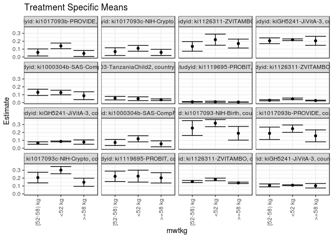

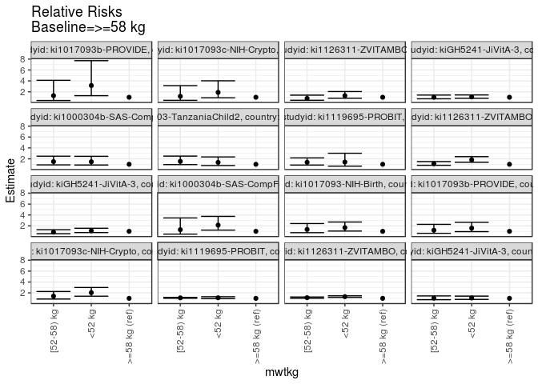

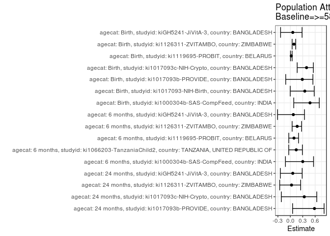

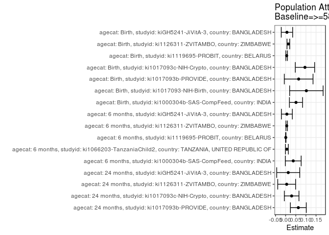

## Results Table

### Parameter: TSM

| agecat | studyid | country | intervention_level | baseline_level | estimate | ci_lower | ci_upper |
| --- | --- | --- | --- | --- | --- | --- | --- |
| Birth | ki1000304b-SAS-CompFeed | INDIA | >=58 kg | NA | 0.0561798 | 0.0184587 | 0.0939008 |
| Birth | ki1000304b-SAS-CompFeed | INDIA | <52 kg | NA | 0.1201456 | 0.0811367 | 0.1591546 |
| Birth | ki1000304b-SAS-CompFeed | INDIA | [52-58) kg | NA | 0.0730337 | 0.0346496 | 0.1114178 |
| Birth | ki1017093-NIH-Birth | BANGLADESH | >=58 kg | NA | 0.1898734 | 0.1033127 | 0.2764342 |
| Birth | ki1017093-NIH-Birth | BANGLADESH | <52 kg | NA | 0.3188406 | 0.2739105 | 0.3637706 |
| Birth | ki1017093-NIH-Birth | BANGLADESH | [52-58) kg | NA | 0.2560976 | 0.1615436 | 0.3506515 |
| Birth | ki1017093b-PROVIDE | BANGLADESH | >=58 kg | NA | 0.1573034 | 0.0815880 | 0.2330187 |
| Birth | ki1017093b-PROVIDE | BANGLADESH | <52 kg | NA | 0.2484663 | 0.2015122 | 0.2954203 |
| Birth | ki1017093b-PROVIDE | BANGLADESH | [52-58) kg | NA | 0.1894737 | 0.1105930 | 0.2683543 |
| Birth | ki1017093c-NIH-Crypto | BANGLADESH | >=58 kg | NA | 0.1475410 | 0.0961219 | 0.1989601 |
| Birth | ki1017093c-NIH-Crypto | BANGLADESH | <52 kg | NA | 0.3018373 | 0.2557099 | 0.3479647 |
| Birth | ki1017093c-NIH-Crypto | BANGLADESH | [52-58) kg | NA | 0.2071429 | 0.1399651 | 0.2743206 |
| Birth | ki1119695-PROBIT | BELARUS | >=58 kg | NA | 0.2035571 | 0.1381438 | 0.2689705 |
| Birth | ki1119695-PROBIT | BELARUS | <52 kg | NA | 0.2250890 | 0.1491063 | 0.3010717 |
| Birth | ki1119695-PROBIT | BELARUS | [52-58) kg | NA | 0.2225532 | 0.1563242 | 0.2887822 |
| Birth | ki1126311-ZVITAMBO | ZIMBABWE | >=58 kg | NA | 0.1398717 | 0.1306668 | 0.1490766 |
| Birth | ki1126311-ZVITAMBO | ZIMBABWE | <52 kg | NA | 0.1834734 | 0.1670814 | 0.1998654 |
| Birth | ki1126311-ZVITAMBO | ZIMBABWE | [52-58) kg | NA | 0.1565638 | 0.1428282 | 0.1702993 |
| Birth | kiGH5241-JiVitA-3 | BANGLADESH | >=58 kg | NA | 0.1030445 | 0.0746347 | 0.1314543 |
| Birth | kiGH5241-JiVitA-3 | BANGLADESH | <52 kg | NA | 0.1099015 | 0.1045943 | 0.1152088 |
| Birth | kiGH5241-JiVitA-3 | BANGLADESH | [52-58) kg | NA | 0.1076417 | 0.0888461 | 0.1264374 |
| 6 months | ki1000304b-SAS-CompFeed | INDIA | >=58 kg | NA | 0.0873787 | 0.0376907 | 0.1370666 |
| 6 months | ki1000304b-SAS-CompFeed | INDIA | <52 kg | NA | 0.1275964 | 0.0982369 | 0.1569559 |
| 6 months | ki1000304b-SAS-CompFeed | INDIA | [52-58) kg | NA | 0.1302326 | 0.0903997 | 0.1700654 |
| 6 months | ki1066203-TanzaniaChild2 | TANZANIA, UNITED REPUBLIC OF | >=58 kg | NA | 0.0366534 | 0.0262546 | 0.0470522 |
| 6 months | ki1066203-TanzaniaChild2 | TANZANIA, UNITED REPUBLIC OF | <52 kg | NA | 0.0493827 | 0.0257847 | 0.0729807 |
| 6 months | ki1066203-TanzaniaChild2 | TANZANIA, UNITED REPUBLIC OF | [52-58) kg | NA | 0.0562347 | 0.0339026 | 0.0785668 |
| 6 months | ki1119695-PROBIT | BELARUS | >=58 kg | NA | 0.0071869 | 0.0053050 | 0.0090687 |
| 6 months | ki1119695-PROBIT | BELARUS | <52 kg | NA | 0.0101570 | 0.0025233 | 0.0177907 |
| 6 months | ki1119695-PROBIT | BELARUS | [52-58) kg | NA | 0.0098127 | 0.0051490 | 0.0144764 |
| 6 months | ki1126311-ZVITAMBO | ZIMBABWE | >=58 kg | NA | 0.0263220 | 0.0215115 | 0.0311325 |
| 6 months | ki1126311-ZVITAMBO | ZIMBABWE | <52 kg | NA | 0.0478692 | 0.0377587 | 0.0579797 |
| 6 months | ki1126311-ZVITAMBO | ZIMBABWE | [52-58) kg | NA | 0.0289449 | 0.0218447 | 0.0360452 |
| 6 months | kiGH5241-JiVitA-3 | BANGLADESH | >=58 kg | NA | 0.0784314 | 0.0511796 | 0.1056831 |
| 6 months | kiGH5241-JiVitA-3 | BANGLADESH | <52 kg | NA | 0.0861593 | 0.0811210 | 0.0911976 |
| 6 months | kiGH5241-JiVitA-3 | BANGLADESH | [52-58) kg | NA | 0.0660295 | 0.0503753 | 0.0816838 |
| 24 months | ki1017093b-PROVIDE | BANGLADESH | >=58 kg | NA | 0.0446429 | 0.0063627 | 0.0829230 |
| 24 months | ki1017093b-PROVIDE | BANGLADESH | <52 kg | NA | 0.1408840 | 0.1050144 | 0.1767536 |
| 24 months | ki1017093b-PROVIDE | BANGLADESH | [52-58) kg | NA | 0.0576923 | 0.0128423 | 0.1025423 |
| 24 months | ki1017093c-NIH-Crypto | BANGLADESH | >=58 kg | NA | 0.0579710 | 0.0189437 | 0.0969984 |
| 24 months | ki1017093c-NIH-Crypto | BANGLADESH | <52 kg | NA | 0.1098901 | 0.0727545 | 0.1470257 |
| 24 months | ki1017093c-NIH-Crypto | BANGLADESH | [52-58) kg | NA | 0.0679612 | 0.0193093 | 0.1166131 |
| 24 months | ki1126311-ZVITAMBO | ZIMBABWE | >=58 kg | NA | 0.1705882 | 0.1139774 | 0.2271991 |
| 24 months | ki1126311-ZVITAMBO | ZIMBABWE | <52 kg | NA | 0.2196970 | 0.1489804 | 0.2904135 |
| 24 months | ki1126311-ZVITAMBO | ZIMBABWE | [52-58) kg | NA | 0.1344538 | 0.0730885 | 0.1958191 |
| 24 months | kiGH5241-JiVitA-3 | BANGLADESH | >=58 kg | NA | 0.2051282 | 0.1478855 | 0.2623709 |
| 24 months | kiGH5241-JiVitA-3 | BANGLADESH | <52 kg | NA | 0.2192725 | 0.2090224 | 0.2295226 |
| 24 months | kiGH5241-JiVitA-3 | BANGLADESH | [52-58) kg | NA | 0.2059859 | 0.1697750 | 0.2421968 |

### Parameter: E(Y)

| agecat | studyid | country | intervention_level | baseline_level | estimate | ci_lower | ci_upper |
| --- | --- | --- | --- | --- | --- | --- | --- |
| Birth | ki1000304b-SAS-CompFeed | INDIA | NA | NA | 0.1072411 | 0.0763212 | 0.1381609 |
| Birth | ki1017093-NIH-Birth | BANGLADESH | NA | NA | 0.2921739 | 0.2549711 | 0.3293768 |
| Birth | ki1017093b-PROVIDE | BANGLADESH | NA | NA | 0.2215686 | 0.1854897 | 0.2576475 |
| Birth | ki1017093c-NIH-Crypto | BANGLADESH | NA | NA | 0.2428977 | 0.2111977 | 0.2745977 |
| Birth | ki1119695-PROBIT | BELARUS | NA | NA | 0.2085796 | 0.1430705 | 0.2740887 |
| Birth | ki1126311-ZVITAMBO | ZIMBABWE | NA | NA | 0.1533152 | 0.1463521 | 0.1602782 |
| Birth | kiGH5241-JiVitA-3 | BANGLADESH | NA | NA | 0.1095860 | 0.1044555 | 0.1147165 |
| 6 months | ki1000304b-SAS-CompFeed | INDIA | NA | NA | 0.1249059 | 0.0994146 | 0.1503973 |
| 6 months | ki1066203-TanzaniaChild2 | TANZANIA, UNITED REPUBLIC OF | NA | NA | 0.0427565 | 0.0338612 | 0.0516519 |
| 6 months | ki1119695-PROBIT | BELARUS | NA | NA | 0.0078837 | 0.0058935 | 0.0098738 |
| 6 months | ki1126311-ZVITAMBO | ZIMBABWE | NA | NA | 0.0315660 | 0.0277605 | 0.0353714 |
| 6 months | kiGH5241-JiVitA-3 | BANGLADESH | NA | NA | 0.0845902 | 0.0797842 | 0.0893962 |
| 24 months | ki1017093b-PROVIDE | BANGLADESH | NA | NA | 0.1072664 | 0.0820169 | 0.1325160 |
| 24 months | ki1017093c-NIH-Crypto | BANGLADESH | NA | NA | 0.0875486 | 0.0630907 | 0.1120065 |
| 24 months | ki1126311-ZVITAMBO | ZIMBABWE | NA | NA | 0.1757720 | 0.1393702 | 0.2121737 |
| 24 months | kiGH5241-JiVitA-3 | BANGLADESH | NA | NA | 0.2180740 | 0.2082038 | 0.2279441 |

### Parameter: RR

| agecat | studyid | country | intervention_level | baseline_level | estimate | ci_lower | ci_upper |
| --- | --- | --- | --- | --- | --- | --- | --- |
| Birth | ki1000304b-SAS-CompFeed | INDIA | >=58 kg | >=58 kg | 1.0000000 | 1.0000000 | 1.000000 |
| Birth | ki1000304b-SAS-CompFeed | INDIA | <52 kg | >=58 kg | 2.1385922 | 1.2224537 | 3.741309 |
| Birth | ki1000304b-SAS-CompFeed | INDIA | [52-58) kg | >=58 kg | 1.3000000 | 0.4894687 | 3.452723 |
| Birth | ki1017093-NIH-Birth | BANGLADESH | >=58 kg | >=58 kg | 1.0000000 | 1.0000000 | 1.000000 |
| Birth | ki1017093-NIH-Birth | BANGLADESH | <52 kg | >=58 kg | 1.6792271 | 1.0420236 | 2.706084 |
| Birth | ki1017093-NIH-Birth | BANGLADESH | [52-58) kg | >=58 kg | 1.3487805 | 0.7501804 | 2.425028 |
| Birth | ki1017093b-PROVIDE | BANGLADESH | >=58 kg | >=58 kg | 1.0000000 | 1.0000000 | 1.000000 |
| Birth | ki1017093b-PROVIDE | BANGLADESH | <52 kg | >=58 kg | 1.5795355 | 0.9417925 | 2.649132 |
| Birth | ki1017093b-PROVIDE | BANGLADESH | [52-58) kg | >=58 kg | 1.2045113 | 0.6374230 | 2.276114 |
| Birth | ki1017093c-NIH-Crypto | BANGLADESH | >=58 kg | >=58 kg | 1.0000000 | 1.0000000 | 1.000000 |
| Birth | ki1017093c-NIH-Crypto | BANGLADESH | <52 kg | >=58 kg | 2.0457859 | 1.3982768 | 2.993141 |
| Birth | ki1017093c-NIH-Crypto | BANGLADESH | [52-58) kg | >=58 kg | 1.4039683 | 0.8721832 | 2.259992 |
| Birth | ki1119695-PROBIT | BELARUS | >=58 kg | >=58 kg | 1.0000000 | 1.0000000 | 1.000000 |
| Birth | ki1119695-PROBIT | BELARUS | <52 kg | >=58 kg | 1.1057779 | 0.9403982 | 1.300242 |
| Birth | ki1119695-PROBIT | BELARUS | [52-58) kg | >=58 kg | 1.0933206 | 1.0210184 | 1.170743 |
| Birth | ki1126311-ZVITAMBO | ZIMBABWE | >=58 kg | >=58 kg | 1.0000000 | 1.0000000 | 1.000000 |
| Birth | ki1126311-ZVITAMBO | ZIMBABWE | <52 kg | >=58 kg | 1.3117265 | 1.1739574 | 1.465664 |
| Birth | ki1126311-ZVITAMBO | ZIMBABWE | [52-58) kg | >=58 kg | 1.1193387 | 1.0030721 | 1.249082 |
| Birth | kiGH5241-JiVitA-3 | BANGLADESH | >=58 kg | >=58 kg | 1.0000000 | 1.0000000 | 1.000000 |
| Birth | kiGH5241-JiVitA-3 | BANGLADESH | <52 kg | >=58 kg | 1.0665444 | 0.8063086 | 1.410771 |
| Birth | kiGH5241-JiVitA-3 | BANGLADESH | [52-58) kg | >=58 kg | 1.0446142 | 0.7560188 | 1.443375 |
| 6 months | ki1000304b-SAS-CompFeed | INDIA | >=58 kg | >=58 kg | 1.0000000 | 1.0000000 | 1.000000 |
| 6 months | ki1000304b-SAS-CompFeed | INDIA | <52 kg | >=58 kg | 1.4602701 | 0.8663107 | 2.461459 |
| 6 months | ki1000304b-SAS-CompFeed | INDIA | [52-58) kg | >=58 kg | 1.4904390 | 0.8935130 | 2.486151 |
| 6 months | ki1066203-TanzaniaChild2 | TANZANIA, UNITED REPUBLIC OF | >=58 kg | >=58 kg | 1.0000000 | 1.0000000 | 1.000000 |
| 6 months | ki1066203-TanzaniaChild2 | TANZANIA, UNITED REPUBLIC OF | <52 kg | >=58 kg | 1.3472893 | 0.7728747 | 2.348619 |
| 6 months | ki1066203-TanzaniaChild2 | TANZANIA, UNITED REPUBLIC OF | [52-58) kg | >=58 kg | 1.5342298 | 0.9417407 | 2.499479 |
| 6 months | ki1119695-PROBIT | BELARUS | >=58 kg | >=58 kg | 1.0000000 | 1.0000000 | 1.000000 |
| 6 months | ki1119695-PROBIT | BELARUS | <52 kg | >=58 kg | 1.4132700 | 0.6610782 | 3.021325 |
| 6 months | ki1119695-PROBIT | BELARUS | [52-58) kg | >=58 kg | 1.3653625 | 0.8580904 | 2.172516 |
| 6 months | ki1126311-ZVITAMBO | ZIMBABWE | >=58 kg | >=58 kg | 1.0000000 | 1.0000000 | 1.000000 |
| 6 months | ki1126311-ZVITAMBO | ZIMBABWE | <52 kg | >=58 kg | 1.8186035 | 1.3754296 | 2.404572 |
| 6 months | ki1126311-ZVITAMBO | ZIMBABWE | [52-58) kg | >=58 kg | 1.0996482 | 0.8098495 | 1.493149 |
| 6 months | kiGH5241-JiVitA-3 | BANGLADESH | >=58 kg | >=58 kg | 1.0000000 | 1.0000000 | 1.000000 |
| 6 months | kiGH5241-JiVitA-3 | BANGLADESH | <52 kg | >=58 kg | 1.0985312 | 0.7726678 | 1.561824 |
| 6 months | kiGH5241-JiVitA-3 | BANGLADESH | [52-58) kg | >=58 kg | 0.8418766 | 0.5501240 | 1.288357 |
| 24 months | ki1017093b-PROVIDE | BANGLADESH | >=58 kg | >=58 kg | 1.0000000 | 1.0000000 | 1.000000 |
| 24 months | ki1017093b-PROVIDE | BANGLADESH | <52 kg | >=58 kg | 3.1558010 | 1.2901595 | 7.719263 |
| 24 months | ki1017093b-PROVIDE | BANGLADESH | [52-58) kg | >=58 kg | 1.2923077 | 0.4061679 | 4.111745 |
| 24 months | ki1017093c-NIH-Crypto | BANGLADESH | >=58 kg | >=58 kg | 1.0000000 | 1.0000000 | 1.000000 |
| 24 months | ki1017093c-NIH-Crypto | BANGLADESH | <52 kg | >=58 kg | 1.8956044 | 0.8924902 | 4.026169 |
| 24 months | ki1017093c-NIH-Crypto | BANGLADESH | [52-58) kg | >=58 kg | 1.1723301 | 0.4388000 | 3.132082 |
| 24 months | ki1126311-ZVITAMBO | ZIMBABWE | >=58 kg | >=58 kg | 1.0000000 | 1.0000000 | 1.000000 |
| 24 months | ki1126311-ZVITAMBO | ZIMBABWE | <52 kg | >=58 kg | 1.2878788 | 0.8111352 | 2.044828 |
| 24 months | ki1126311-ZVITAMBO | ZIMBABWE | [52-58) kg | >=58 kg | 0.7881773 | 0.4482826 | 1.385785 |
| 24 months | kiGH5241-JiVitA-3 | BANGLADESH | >=58 kg | >=58 kg | 1.0000000 | 1.0000000 | 1.000000 |
| 24 months | kiGH5241-JiVitA-3 | BANGLADESH | <52 kg | >=58 kg | 1.0689534 | 0.8052996 | 1.418927 |
| 24 months | kiGH5241-JiVitA-3 | BANGLADESH | [52-58) kg | >=58 kg | 1.0041813 | 0.7181683 | 1.404100 |

### Parameter: PAR

| agecat | studyid | country | intervention_level | baseline_level | estimate | ci_lower | ci_upper |
| --- | --- | --- | --- | --- | --- | --- | --- |
| Birth | ki1000304b-SAS-CompFeed | INDIA | >=58 kg | NA | 0.0510613 | 0.0186947 | 0.0834278 |
| Birth | ki1017093-NIH-Birth | BANGLADESH | >=58 kg | NA | 0.1023005 | 0.0197297 | 0.1848713 |
| Birth | ki1017093b-PROVIDE | BANGLADESH | >=58 kg | NA | 0.0642653 | -0.0066829 | 0.1352134 |
| Birth | ki1017093c-NIH-Crypto | BANGLADESH | >=58 kg | NA | 0.0953567 | 0.0476674 | 0.1430461 |
| Birth | ki1119695-PROBIT | BELARUS | >=58 kg | NA | 0.0050224 | 0.0011118 | 0.0089331 |
| Birth | ki1126311-ZVITAMBO | ZIMBABWE | >=58 kg | NA | 0.0134435 | 0.0068599 | 0.0200271 |
| Birth | kiGH5241-JiVitA-3 | BANGLADESH | >=58 kg | NA | 0.0065415 | -0.0215745 | 0.0346575 |
| 6 months | ki1000304b-SAS-CompFeed | INDIA | >=58 kg | NA | 0.0375273 | -0.0015559 | 0.0766105 |
| 6 months | ki1066203-TanzaniaChild2 | TANZANIA, UNITED REPUBLIC OF | >=58 kg | NA | 0.0061032 | -0.0010196 | 0.0132259 |
| 6 months | ki1119695-PROBIT | BELARUS | >=58 kg | NA | 0.0006968 | -0.0002776 | 0.0016712 |
| 6 months | ki1126311-ZVITAMBO | ZIMBABWE | >=58 kg | NA | 0.0052440 | 0.0015916 | 0.0088964 |
| 6 months | kiGH5241-JiVitA-3 | BANGLADESH | >=58 kg | NA | 0.0061588 | -0.0208255 | 0.0331431 |
| 24 months | ki1017093b-PROVIDE | BANGLADESH | >=58 kg | NA | 0.0626236 | 0.0234443 | 0.1018028 |
| 24 months | ki1017093c-NIH-Crypto | BANGLADESH | >=58 kg | NA | 0.0295776 | -0.0065257 | 0.0656810 |
| 24 months | ki1126311-ZVITAMBO | ZIMBABWE | >=58 kg | NA | 0.0051837 | -0.0388808 | 0.0492483 |
| 24 months | kiGH5241-JiVitA-3 | BANGLADESH | >=58 kg | NA | 0.0129458 | -0.0438512 | 0.0697427 |

### Parameter: PAF

| agecat | studyid | country | intervention_level | baseline_level | estimate | ci_lower | ci_upper |
| --- | --- | --- | --- | --- | --- | --- | --- |
| Birth | ki1000304b-SAS-CompFeed | INDIA | >=58 kg | NA | 0.4761356 | 0.0833933 | 0.7005980 |
| Birth | ki1017093-NIH-Birth | BANGLADESH | >=58 kg | NA | 0.3501356 | -0.0013667 | 0.5782527 |
| Birth | ki1017093b-PROVIDE | BANGLADESH | >=58 kg | NA | 0.2900467 | -0.1113089 | 0.5464505 |
| Birth | ki1017093c-NIH-Crypto | BANGLADESH | >=58 kg | NA | 0.3925798 | 0.1664771 | 0.5573496 |
| Birth | ki1119695-PROBIT | BELARUS | >=58 kg | NA | 0.0240792 | 0.0040442 | 0.0437112 |
| Birth | ki1126311-ZVITAMBO | ZIMBABWE | >=58 kg | NA | 0.0876854 | 0.0438469 | 0.1295140 |
| Birth | kiGH5241-JiVitA-3 | BANGLADESH | >=58 kg | NA | 0.0596928 | -0.2351840 | 0.2841734 |
| 6 months | ki1000304b-SAS-CompFeed | INDIA | >=58 kg | NA | 0.3004444 | -0.1172838 | 0.5619931 |
| 6 months | ki1066203-TanzaniaChild2 | TANZANIA, UNITED REPUBLIC OF | >=58 kg | NA | 0.1427420 | -0.0381470 | 0.2921125 |
| 6 months | ki1119695-PROBIT | BELARUS | >=58 kg | NA | 0.0883854 | -0.0371253 | 0.1987070 |
| 6 months | ki1126311-ZVITAMBO | ZIMBABWE | >=58 kg | NA | 0.1661281 | 0.0439024 | 0.2727287 |
| 6 months | kiGH5241-JiVitA-3 | BANGLADESH | >=58 kg | NA | 0.0728074 | -0.3077882 | 0.3426412 |
| 24 months | ki1017093b-PROVIDE | BANGLADESH | >=58 kg | NA | 0.5838134 | 0.0552311 | 0.8166628 |
| 24 months | ki1017093c-NIH-Crypto | BANGLADESH | >=58 kg | NA | 0.3378422 | -0.2166810 | 0.6396320 |
| 24 months | ki1126311-ZVITAMBO | ZIMBABWE | >=58 kg | NA | 0.0294913 | -0.2564994 | 0.2503878 |
| 24 months | kiGH5241-JiVitA-3 | BANGLADESH | >=58 kg | NA | 0.0593641 | -0.2405836 | 0.2867906 |